# Simulating issues with estimating discrimination

Chris Berg

1/15/2020

# Introduction

The purpose of this simulation (inspired by a similar simulation done in Stata by Dr. Scott Cunningham of Baylor Univ.) is to illustrate how some controls can seem sensible to include in a regression, but actually be produce completely “wrong” results (or, specifically, produce estimates biased in a direction *opposite* of the causal relationship).

# Data Generating Process

Let’s consider a situation in which wages depend on **unobserved** ability $A_i$ and some measure of status $C_i$. Ability further affects this standing as well, but so does discrimination $D_i$. For individuals facing discrimination ($D_i = 1$), standing is otherwise lower than it would be if they were a “non-oppressed”-type. An important part of this is, regardless of how one interprets the model, ability affects both status/standing as well as wages on the job– no matter who you are, if you have higher ability you can get a better job *and* get paid more. Remember– our fictitious econometrician *can’t* see or include this in their regressions.

In practice, this could perhaps be the labor market for science or engineering; fields where women have faced sexism and unwelcomeness from the academy. In this case $C_i$ would be some measure of “education status,” and women would be less inclined ($\bar C_D < \bar C$ where $\bar C_D$ is the group average education for the discriminated group) to achieve educational standing in these fields. Alternatively $C_i$ could represent some measure of “occupational standing” where under-represented groups are more-inclined to be “shut-out” from higher-status jobs, even if they have the same innate ability as the rest of the population.

With that said, our model is:

$$C_i = \mu_c + \beta_D D_i + \beta_A A_i + \epsilon_i$$
$$w_i = \mu_w + \alpha_C C_i + \alpha_A A_i + \nu_i$$
[**Note, we are ruling-out a channel from wages back to status/standing.** Including such a link would of course produce a reduced-form dependency of ($w$ , $C$) on ($D$ , $A$).]

# Simulation model

Click “code” below to show the code for the model parameters, as well as the construction of the data-generating process.

```r
a_c = 0 # "status" intercept
a_w = 10 # wage intercept
sd_c = 1 # "randomness" alt. role of luck in status
b_disc = 1 # parameter governing discrimination penalty (0-1)
b_c_disc = -1 # discrimination hurts your status
b_c_ability = 2 # natural ability determines status
b_w_c = 2 # status leads ot higher wages
b_w_ability = 2 # talent pays off

D = rbinom(10000 , 1 , 0.5) # half the population is subject to discrimination in this example
ability = rnorm(10000) # ability independent of any variable or model parameter
discrimination = b_disc*D # targets of discrimination

# DGP equations

C = a_c + b_c_disc*discrimination + b_c_ability*ability + rnorm(10000, mean = 0 , sd = sd_c) # top eqn above
wage = a_w + b_w_c*C + b_w_ability*ability + rnorm(10000)  # bottom eqn above
plot_df = bind_cols( C = C , wage = wage , ability = ability , D = discrimination)
```

# Estimation

First, just to see that there’s “no funny business,” let’s look at the results from our “God regression” that includes unobserved ability– which we will of course rule-out the econometrician being able to estimate.

```r
true_wage = lm(wage ~ C + ability ) # God regression

summary(true_wage)
```

```
##
## Call:
## lm(formula = wage ~ C + ability)
##
## Residuals:
##     Min      1Q  Median      3Q     Max
## -3.6937 -0.6607  0.0051  0.6682  4.1203
##
## Coefficients:
##             Estimate Std. Error t value Pr(>|t|)
## (Intercept) 9.991789   0.010911  915.77   <2e-16 ***
## C           1.985766   0.008841  224.61   <2e-16 ***
## ability     2.017155   0.020288   99.43   <2e-16 ***
## ---
## Signif. codes:  0 '***' 0.001 '**' 0.01 '*' 0.05 '.' 0.1 ' ' 1
##
## Residual standard error: 0.9922 on 9997 degrees of freedom
## Multiple R-squared:  0.9768, Adjusted R-squared:  0.9768
## F-statistic: 2.108e+05 on 2 and 9997 DF,  p-value: < 2.2e-16
```

As we can clearly see, OLS correctly estimates the DGP for wages.

What about an econometrician tasked with measuring discriminatory wage gaps? Their first instinct might be to look at the raw wage gap between the discriminated group and the rest of the population by regressing wages on an indicator for being in the discriminated class:

```r
ecms_wage = lm(wage ~ discrimination ) # non-Godly regression

summary(ecms_wage)
```

```
##
## Call:
## lm(formula = wage ~ discrimination)
##
## Residuals:
##      Min       1Q   Median       3Q      Max
## -22.5123  -4.4375  -0.0094   4.2955  22.8203
##
## Coefficients:
##                Estimate Std. Error t value Pr(>|t|)
## (Intercept)    10.00524    0.09072   110.3   <2e-16 ***
## discrimination -1.95920    0.12888   -15.2   <2e-16 ***
## ---
## Signif. codes:  0 '***' 0.001 '**' 0.01 '*' 0.05 '.' 0.1 ' ' 1
##
## Residual standard error: 6.444 on 9998 degrees of freedom
## Multiple R-squared:  0.02259,    Adjusted R-squared:  0.02249
## F-statistic: 231.1 on 1 and 9998 DF,  p-value: < 2.2e-16
```

This correctly estimates what you’d if you plugged-in the status variable into wage, and estimated the effect of discrimination. This is what the media might quote as the “discrimination gap”– the mean difference in earnings between the discriminated and non-discriminated class.

What if someone told the econometrician “Actually, members of the discriminated class simply *appear* to have a lower wage, but they just *choose* to [not get a high-status education; go into a high-status occupation; etc.] so you have to control for $C_i$!” Suppose, then, the econometrician estimates the wage equation with $C_i$ included.

```r
ecms_wage_bad = lm(wage ~ discrimination + C)

summary(ecms_wage_bad)
```

```
##
## Call:
## lm(formula = wage ~ discrimination + C)
##
## Residuals:
##     Min      1Q  Median      3Q     Max
## -5.4957 -0.9061 -0.0066  0.9058  5.2101
##
## Coefficients:
##                 Estimate Std. Error t value Pr(>|t|)
## (Intercept)    10.036890   0.019011  527.96   <2e-16 ***
## discrimination  0.749051   0.027627   27.11   <2e-16 ***
## C               2.788239   0.005976  466.54   <2e-16 ***
## ---
## Signif. codes:  0 '***' 0.001 '**' 0.01 '*' 0.05 '.' 0.1 ' ' 1
##
## Residual standard error: 1.35 on 9997 degrees of freedom
## Multiple R-squared:  0.9571, Adjusted R-squared:  0.9571
## F-statistic: 1.115e+05 on 2 and 9997 DF,  p-value: < 2.2e-16
```

We’ve estimated a *positive* effect of being in a discriminated group! But this clearly isn’t right because as the Gods of this simulation we **know** that this is false.

# Why does this happen?

This illustrates what happens when one *conditions on a “collider.”* Here, $C_i$ (education; occupation; etc) is called a “collider” (see Scott Cunningham’s *Mixtape* for a deeper treatment of what colliders are).

The intuitive reason behind this bias is that we could’ve conditioned on status *or* a dummy for discriminated group membership, but including both is forcing ourselves to compare discriminated and non-discriminated individuals with the same fixed level of status $\tilde C$. This level is indicated in the density plot below with the blue vertical line, which for convenience is chosen as the mean of the non-discriminated status level.

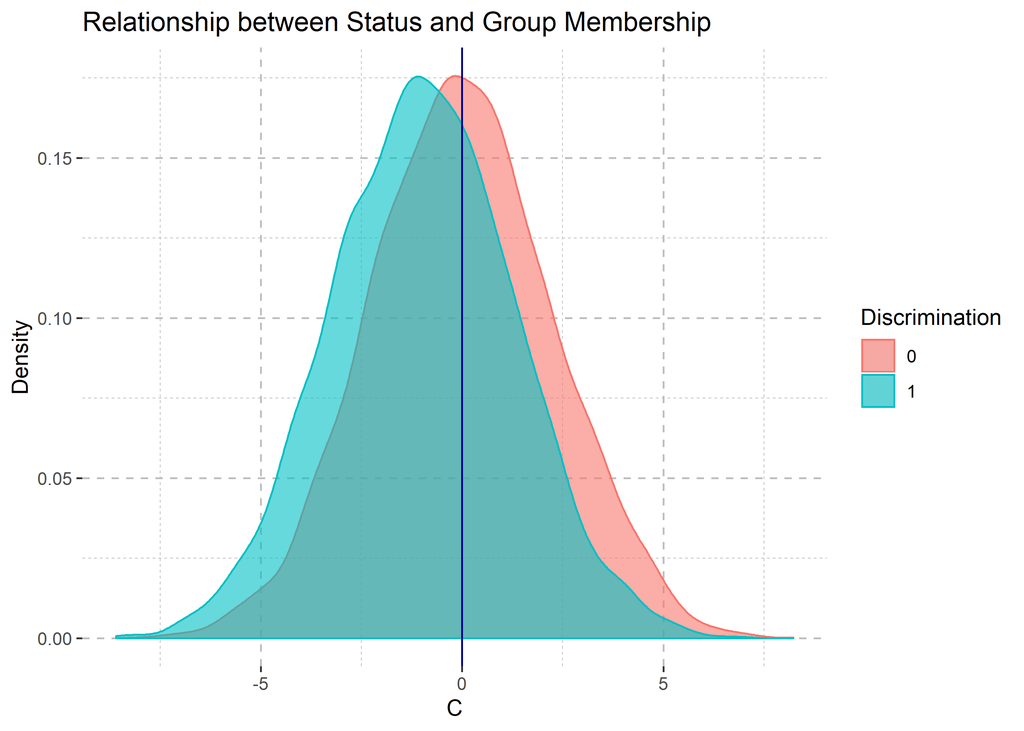

```r
chris_theme =  theme( panel.background = element_rect( fill = 'white' ) ,
                      panel.grid = element_line( linetype = 2 ,
                                                 color = 'grey'))

h = ggplot( data = plot_df ,
            aes(x = C ,
                color = as.factor(D) ,
                fill = as.factor(D)
            )
)

h + geom_density(alpha = 0.6) +
  labs(title = "Relationship between Status and Group Membership" ,
       color = "Discrimination" ,
       fill = "Discrimination" ,
       x = "C" ,
       y = "Density"
  ) +
  geom_vline( xintercept = 0  ,
              color = "darkblue" ) +
  chris_theme
```

The first thing worth keeping in mind is that most of the variation in status $C$ comes from variation in ability, which is distributed independently of discrimination. Our fixed $\tilde C$ intersects the distribution of discriminated individuals’ status much “further to the right” in their distribution, implying those discriminated individuals with a status equal to $\tilde C$ have higher ability. In other words, the only individuals who face discrimination that could get the same $\tilde C$ as the non-discriminated (other than random variation in $C$), are those who have a higher average ability than the non-discriminated group.

…But these are the very people who also receive a higher wage! To see this, look at the scatterplot below of wages on status– with color-coding by whether the individual is discriminated-against or not.

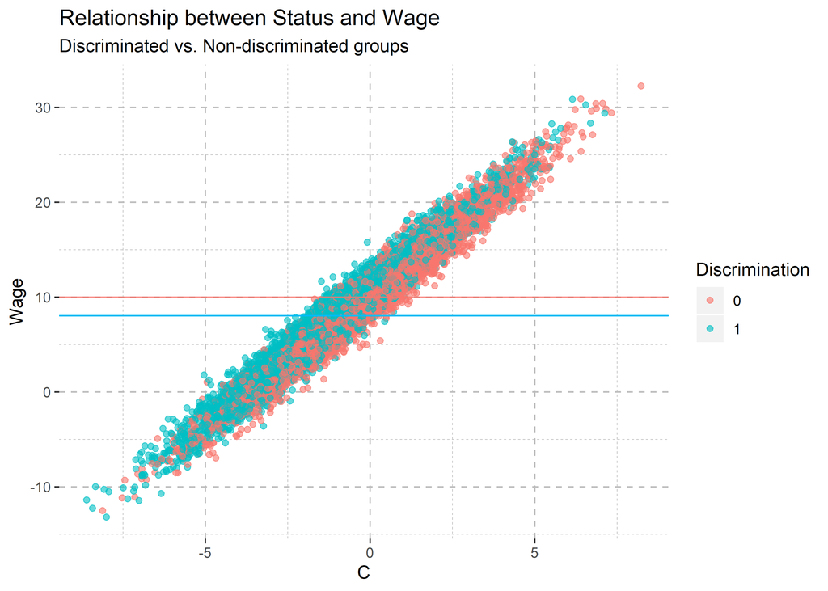

```r
g = ggplot( data = plot_df ,
            aes(x = C ,
                y = wage ,
                color = as.factor(D)
            )
)

g + geom_point(alpha = 0.6) +
  labs(title = "Relationship between Status and Wage" ,
       subtitle = "Discriminated vs. Non-discriminated groups",
       color = "Discrimination" ,
       x = "C" ,
       y = "Wage"
  ) +
  geom_hline(yintercept = mean(
    subset(
      plot_df ,
      plot_df$D==1
      )$wage ,
    alpha = 0.5
  ) ,
  color = '#00BCF4' ) +
  geom_hline( yintercept = mean(
    subset(plot_df ,
    plot_df$D == 0
    )$wage ) ,
    color = '#F8766D',
    alpha = 0.75 ) +
chris_theme
```

Horizontal lines added to highlight the respective group means, and show that the discriminated group indeed receives a lower average wage. A discerning observer might also see that *for a given occupational level,* the discriminated group has a *higher* average wage! To see this clearly, let’s zoom-in on these data a bit and replace the full scatter plot with two equivalent density contours for the non-/discriminated, and add a line at an arbitrary “status” level (here $-1$).

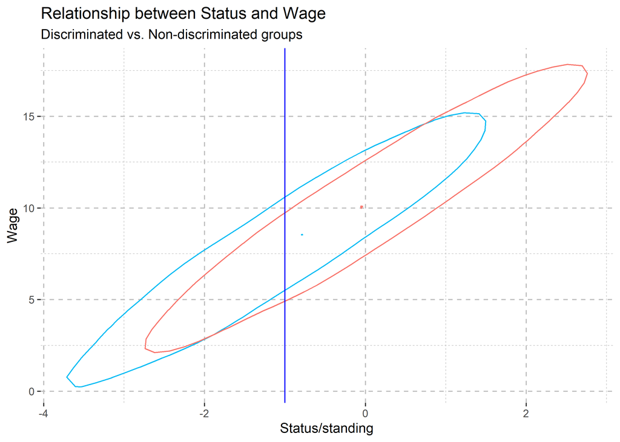

```r
p = ggplot()

p + geom_density_2d(data = plot_df %>% filter( D == 1) ,
            aes(x = C ,
                y = wage
            ) ,
            color = '#00BCF4' ,
            bins = 2) +
  geom_density_2d(data = plot_df %>% filter( D == 0) ,
             aes(x = C ,
                 y = wage
             ) ,
             color = '#F8766D' ,
             bins = 2) +
  geom_vline( xintercept = -1 ,
              color = "blue") +
  labs(title = "Relationship between Status and Wage" ,
       subtitle = "Discriminated vs. Non-discriminated groups",
       color = "Discrimination" ,
       x = "Status/standing" ,
       y = "Wage"
  ) +
  theme( panel.background = element_rect( fill = 'white') ,
         panel.grid = element_line( linetype = 2 ,
                                    color = 'grey'))
```

So while discrimination lowers the average wage of the discriminated as a group (equal to the distance between the horizontal lines of the scatterplot), conditioning on our status attainment variable like occupational standing, education, etc. would falsely suggest that the discriminated receive higher wages. In reality they must be more skilled the get the same “job”/“degree”/etc., but once they achieve it, they enjoy a higher return for their skill.